# State MSM Profile: **South Dakota**

### Background & Methods

In 2015-2016, researchers at Emory University partnered with colleagues at the Centers for Disease Control and Prevention (CDC) to develop methods to estimate the number of men who have sex with men (MSM) residing in each county in the United States. Using population and housing data from the [American Community Survey](https://www.census.gov/programs-surveys/acs/) and estimates from two peer-reviewed publications ([Oster et al., 2015](http://www.ncbi.nlm.nih.gov/pubmed/26115985) & [Purcell et al., 2012](http://www.ncbi.nlm.nih.gov/pubmed/23049658)), they derived an indirect estimate of MSM population sizes that took into account both the urbanicity of the county as well as its density of households with a male householder and a male same-sex partner.

The full methodology is published in the *Journal of Medical Internet Research - Public Health and Surveillance*:

> [Grey JA, Bernstein KT, Sullivan PS, Purcell DW, Chesson HW, Gift TL, Rosenberg ES. Estimating the population sizes of men who have sex with men in US states and counties using data from the American Community Survey. JMIR Public Health Surveill 2016;2(1):e14. DOI: 10.2196/publichealth.5365](http://publichealth.jmir.org/2016/1/e14/)

### Overview of MSM in South Dakota

An estimated **5,171** men who have sex with men (MSM) resided in South Dakota in 2013, representing 0.1% of the 4,503,084 MSM in the United States. Of the 309,108 adult men of South Dakota, 1.7% had had sex with another man in the past 5 years, which was less than the overall percentage of adult men in the United States who were MSM (3.9%).

Most MSM in South Dakota resided in counties within medium or small metropolitan areas (58.7%). No MSM in South Dakota resided in a large metropolitan area.

##### **Percentage of MSM by urbanicity, United States and South Dakota, 2013**

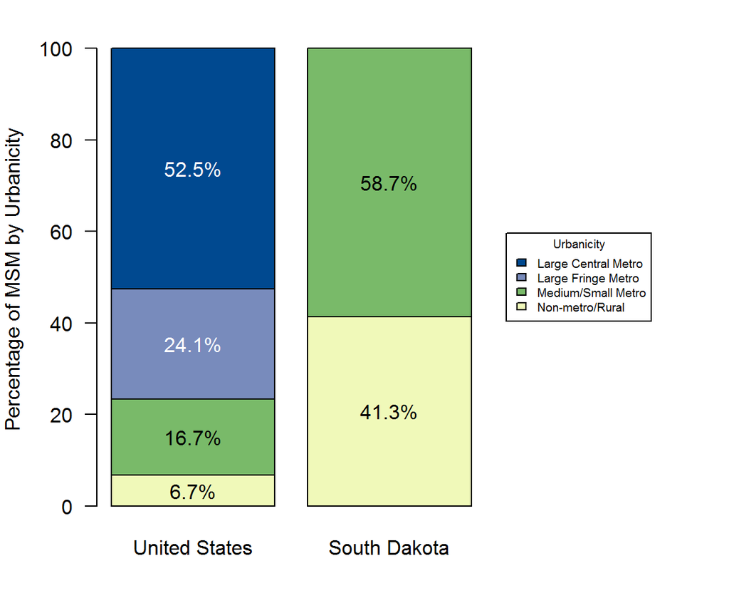

### MSM in South Dakota Counties

Among counties or county-equivalent areas in South Dakota, Minnehaha County had the largest population of MSM at 1,342, representing 26.0% of all MSM in the state. Butte County had the highest percentage of MSM among adult men in South Dakota at 4.0%. This was greater than the percentage for South Dakota as a whole, which was 1.7% of adult men.

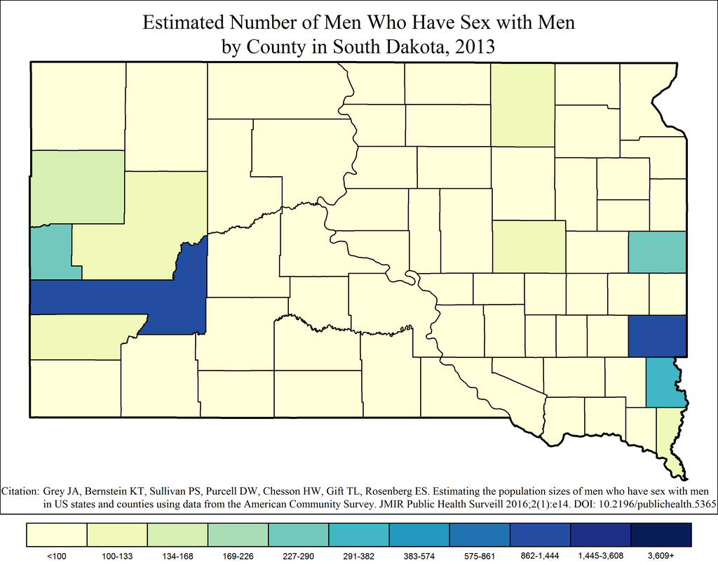

Note: Range cutpoints for the map are based on the distribution of MSM among all counties in the United States.

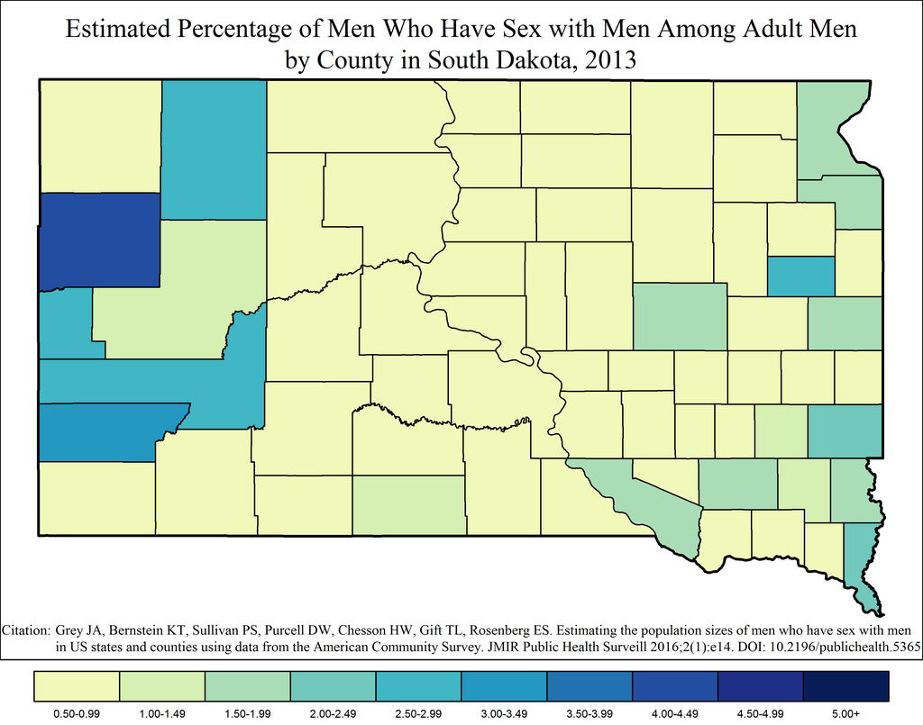

### MSM in South Dakota Metropolitan Statistical Areas

#### Sioux Falls Metropolitan Statistical Area

The Sioux Falls MSA had the largest metropolitan population of MSM in South Dakota at 1,714, or 33.1% of all MSM in the state. Of the 85,720 adult men in Sioux Falls, an estimated 2.0% were MSM.

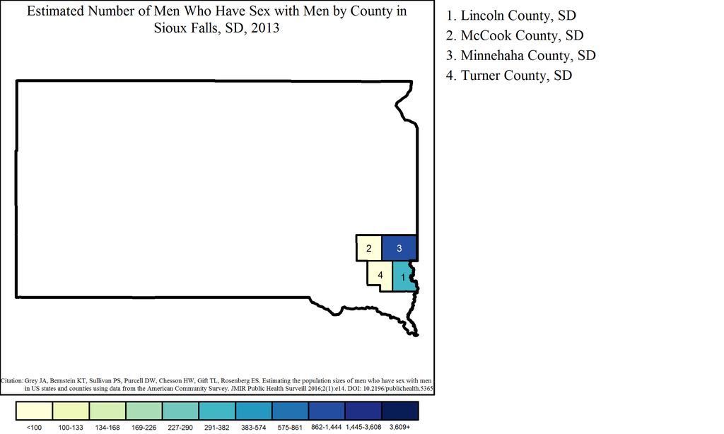

Note: Range cutpoints for the map are based on the distribution of MSM among all counties in the United States.

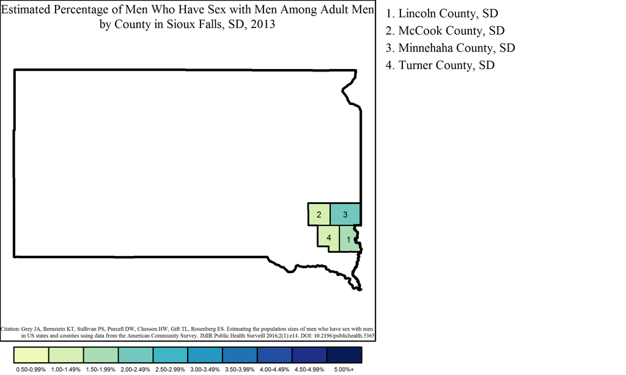

#### Rapid City Metropolitan Statistical Area

The Rapid City MSA had a population of 1,209 MSM, or 23.4% of all MSM in South Dakota. Of the 51,773 adult men in Rapid City, an estimated 2.3% were MSM.

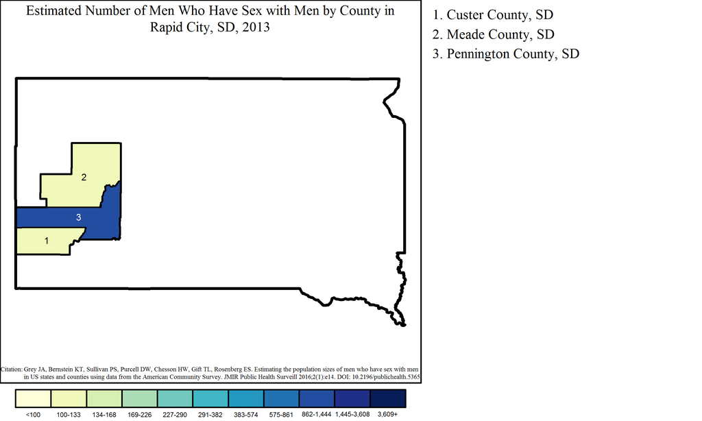

Note: Range cutpoints for the map are based on the distribution of MSM among all counties in the United States.

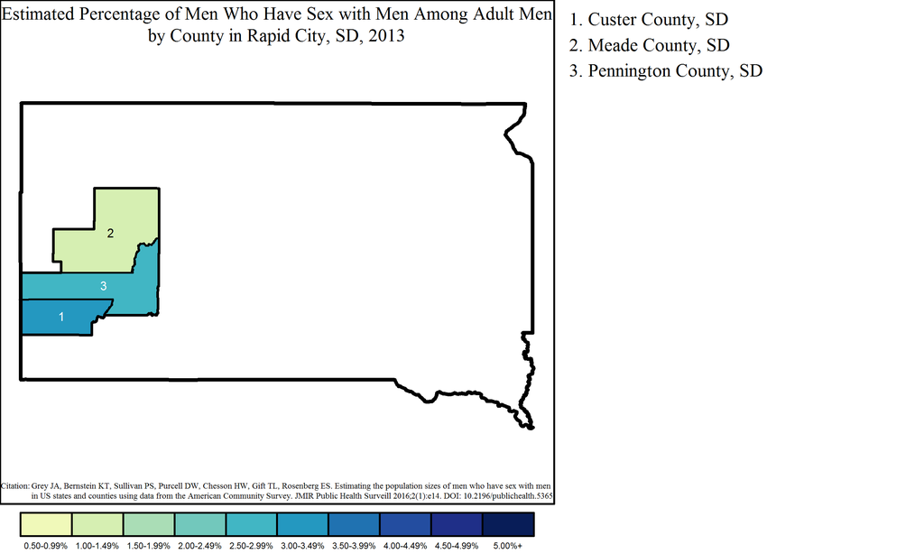

#### Sioux City Metropolitan Statistical Area

The Sioux City MSA overlaps three states: Iowa, Nebraska and South Dakota. The South Dakota portion of the MSA had 111 MSM, or 2.1% of all MSM in the state and 11.5% of the 967 MSM in the MSA. Of 5,352 adult men in the South Dakota part of Sioux City, 2.1% were MSM. This was greater than the overall percentage of MSM among adult men in the MSA, which was 1.6% of adult men (967 out of 60,459).

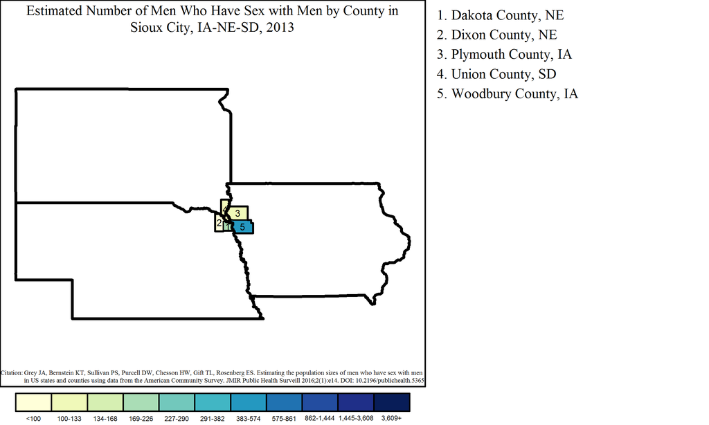

Note: Range cutpoints for the map are based on the distribution of MSM among all counties in the United States.

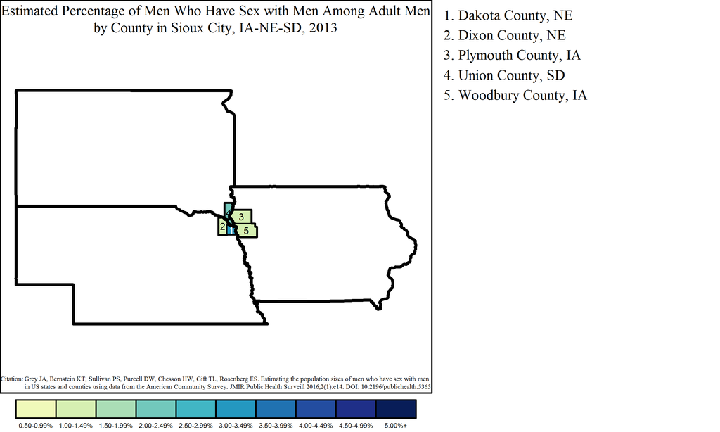